# Proyecto Estadística Descriptiva e Inferencia

## Ejercicio 1

**La siguiente tabla contiene, en un editable Excel, dos variables: la primera es dicotómica con valores 1 (predinástico temprano) y 2 (predinástico tardío) y la segunda contiene la anchura de cráneos (mm.) encontrados en un yacimiento arqueológico. La idea es analizar si existen diferencias en la longitud de la anchura de los cráneos egipcios a medida que pasa el tiempo. Creo que mayoritariamente tenemos una idea de que las cabezas egipcias son más alargadas y cuando ya llegamos a los romanos son más redondeadas. El cine se ha encargado de hacer muy gráfico todo esto.**

**Se pide:**

**a) obtener con Python las diferentes medidas de centralización y dispersión, asimetría y curtosis estudiadas. Así mismo, obtener el diagrama de caja y bigotes. Se debe hacer por separado para la sub-muestra de los cráneos del predinástico temprano y para la sub-muestra de los del predinástico tardío. Comentar los resultados obtenidos. Estos comentarios son obligatorios.**

**b) Determinar si cada una de las dos sub-muestras sigue una distribución normal utilizando el test de Kolmogorov-Smirnov.**

Comenzamos importando todas las librerías necesarias:

```python
import pandas  as pd
import matplotlib.pyplot as plt
import seaborn as sns
import warnings
import math as mt
from scipy import stats
import numpy as np
from sklearn.preprocessing import StandardScaler

sns.set_style('darkgrid')
warnings.filterwarnings('ignore')
```

## Ejercicio 1

### Apartado a)

En primer lugar cargamos el excel con los datos para el ejercicio. Se encuentra en el directorio `data` dentro del directorio de trabajo:

```python
df = pd.read_excel('data\datosejercicioevaluacionanchuras.xlsx')
```

En segundo lugar separamos las muestras de acuerdo a las épocas históricas. Por un lado tomaremos los valores del periodo histórico temprano (los que tienen valor "1" en la columna de *Época histórica*) y los del periodo histórico tardío (los que tienen valor "2"):

```python
#muestra de predinastico temprano
df_1 = df[df['Época histórica']==1]
print(df_1)
```

```
    Época histórica  Anchura del cráneo
0                 1                 133
1                 1                 131
2                 1                 131
3                 1                 132
4                 1                 134
5                 1                 131
6                 1                 132
7                 1                 132
8                 1                 131
9                 1                 131
10                1                 132
11                1                 131
12                1                 131
13                1                 132
```

[output cut: 16 more lines]

```python
#muestra de predinastico tardio
df_2 = df[df['Época histórica']==2]
print(df_2)
```

```
    Época histórica  Anchura del cráneo
30                2                 132
31                2                 133
32                2                 131
33                2                 133
34                2                 133
35                2                 133
36                2                 134
37                2                 132
38                2                 131
39                2                 133
40                2                 133
41                2                 133
42                2                 132
43                2                 133
```

[output cut: 16 more lines]

#### MEDIDAS DE TENDENCIA CENTRAL - NO CENTRAL - DISPERSION - FORMA - PREDINASTICO TEMPRANO

Puesto que trabajamos con Dataframes de la librería *Pandas* podemos beneficiarnos de algunas funciones de la propia librería para tomar las primeras medidas de tendencia central, en concreto la **media**, **desviación típica**, el valor **mínimo** y el **primer cuaetil**. Para ello usamos la función `describe()` que calcula automáticamente estos valores para una muestra dada.

```python
valores_1 = pd.DataFrame(df_1['Anchura del cráneo'].describe())
valores_1.reset_index(inplace=True)
valores_1.rename(columns={'index':'Medida'},inplace = True)
valores_1.head(5)
```

|  | Medida | Anchura del cráneo |
| --- | --- | --- |
| 0 | count | 30.000000 |
| 1 | mean | 131.533333 |
| 2 | std | 0.819307 |
| 3 | min | 130.000000 |
| 4 | 25% | 131.000000 |

Calculamos el resto de medidas a continuación:

Comenzamos con la moda, para ello usamos la función `mode()` de la librería *Pandas*. Cabe destacar, en este caso, la existencia de dos modas:

```python
#calculo de la moda para grupo 1 (temprano)
print("En este caso hay dos modas: ")
print(df_1['Anchura del cráneo'].mode())

moda_1 = df_1['Anchura del cráneo'].mode()[0]
moda_2 = df_1['Anchura del cráneo'].mode()[1]
```

```
En este caso hay dos modas:
0    131
1    132
Name: Anchura del cráneo, dtype: int64
```

A continuación calculamos el rango de valores que toma la variable (la diferencia entre el valor máximo y el mínimo):

```python
#calculo del rango (valor maximo - valor minimo)
rango = df_1['Anchura del cráneo'].max() - df_1['Anchura del cráneo'].min()
print(rango)
```

```
4
```

Como podemos observar, comparado con la magnitud de los valores, el rango es **pequeño**.

Por otro lado calculamos la varianza, de nuevo con ayuda de la función `var()` de *Pandas*:

```python
#calculo de la varianza
varianza = df_1['Anchura del cráneo'].var()
print(varianza)
```

```
0.6712643678160921
```

A continuación calculamos el **Coeficiente de variación de Pearson**, una medida de la variabilidad relativa de una distribución de datos:

```python
coef_var_P = valores_1.loc[2][1]/valores_1.loc[1][1]
print(coef_var_P)
```

```
0.006228894440395486
```

La interpretación sería que la variabilidad relativa de los datos en comparación con la media es bastante baja, indicando una dispersión relativamente pequeña en relación con la media, lo que sugiere que los valores se concentran en torno a la media.

Realizamos ahora un estudio de la asimetría y curtosis, para ello comenzamos creando unas columnas auxiliares en nuestro dataframe original, que serán la diferencia entre cada elemento de la muestra substrayendo la media y elevando al cubo (para el coeficiente de asimetría de Fisher) y lo mismo pero elevando a la cuarta para el de curtosis:

```python
df_1['Xi - Media'] = df_1['Anchura del cráneo'] - valores_1.loc[1][1]
df_1['(Xi - Media)*3'] = df_1['Xi - Media']**3
df_1['(Xi - Media)*4'] = df_1['Xi - Media']**4
df_1.head(5)
```

|  | Época histórica | Anchura del cráneo | Xi - Media | (Xi - Media)*3 | (Xi - Media)*4 |
| --- | --- | --- | --- | --- | --- |
| 0 | 1 | 133 | 1.466667 | 3.154963 | 4.627279 |
| 1 | 1 | 131 | -0.533333 | -0.151704 | 0.080909 |
| 2 | 1 | 131 | -0.533333 | -0.151704 | 0.080909 |
| 3 | 1 | 132 | 0.466667 | 0.101630 | 0.047427 |
| 4 | 1 | 134 | 2.466667 | 15.008296 | 37.020464 |

Ahora calculamos el coeficiente de asimetría de Fisher:

```python
Coef_Fisher=df_1['(Xi - Media)*3'].sum()/((df_1['Época histórica'].count()-1)*mt.pow(valores_1.loc[2][1],3))
print(Coef_Fisher)
```

```
0.6459405126888941
```

Calculamos a continuación el *coeficiente de Curtosis*:

```python
coeficiente_Curtosis = df_1['(Xi - Media)*4'].sum()/((df_1['Época histórica'].count()-1)*mt.pow(valores_1.loc[2][1],4)) -3
print(coeficiente_Curtosis)
```

```
1.1608932257459212
```

Obtenemos un coeficiente de curtosis **mayor que 0** por lo que podemos anticipar una distribución **leptocúritca**.

Vamos a representar los datos en un histograma para ilustrar esto, colocamos en el histograma y una línea constante en la mediana, para observar el comportmiento-forma de la distribución.

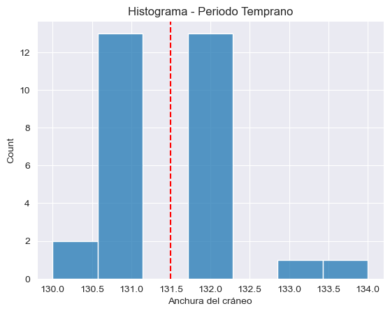

```python
sns.histplot(data=df_1['Anchura del cráneo'] )
plt.axvline(x=valores_1.loc[5][1], color='red', linestyle='--')
plt.title('Histograma - Periodo Temprano')
plt.show()
```

Finalmente representamos conjuntamente todas las medidas calculadas para esta distribución:

```python
Medida = ['moda', 'rango', 'varianza', 'CoeficientePerson', 'CoeficienteFisher', 'CoeficienteCurtosis']
Anchura_del_Craneo_moda_1 = [moda_1, rango, varianza, coef_var_P, Coef_Fisher, coeficiente_Curtosis]
Anchura_del_Craneo_moda_2 = [moda_2, rango, varianza, coef_var_P, Coef_Fisher, coeficiente_Curtosis]

medidas_moda_1 = pd.DataFrame({'Medida': Medida, 'Anchura del cráneo': Anchura_del_Craneo_moda_1})
medidas_moda_2 = pd.DataFrame({'Medida': Medida, 'Anchura del cráneo': Anchura_del_Craneo_moda_2})

# Merge the DataFrames on the "Medida" column
merged_df = pd.merge(medidas_moda_1, medidas_moda_2, on='Medida', suffixes=('_moda_1', '_moda_2'))

# Print the resulting DataFrame
print(merged_df)
```

```
                Medida  Anchura del cráneo_moda_1  Anchura del cráneo_moda_2
0                 moda                 131.000000                 132.000000
1                rango                   4.000000                   4.000000
2             varianza                   0.671264                   0.671264
3    CoeficientePerson                   0.006229                   0.006229
4    CoeficienteFisher                   0.645941                   0.645941
5  CoeficienteCurtosis                   1.160893                   1.160893
```

#### MEDIDAS PERIODO TEMPRANO

Unimos todas las medidas de tendencia central, no central, forma y variabiliad en un solo dataframe por cada valor de la moda(en este caso había dos modas):

```python
valores_moda_1 = pd.concat([valores_1,medidas_moda_1],ignore_index=True)
valores_moda_1
```

|  | Medida | Anchura del cráneo |
| --- | --- | --- |
| 0 | count | 30.000000 |
| 1 | mean | 131.533333 |
| 2 | std | 0.819307 |
| 3 | min | 130.000000 |
| 4 | 25% | 131.000000 |
| 5 | 50% | 131.500000 |
| 6 | 75% | 132.000000 |
| 7 | max | 134.000000 |
| 8 | moda | 131.000000 |
| 9 | rango | 4.000000 |
| 10 | varianza | 0.671264 |
| 11 | CoeficientePerson | 0.006229 |
| 12 | CoeficienteFisher | 0.645941 |
| 13 | CoeficienteCurtosis | 1.160893 |

```python
valores_moda_2 = pd.concat([valores_1,medidas_moda_2],ignore_index=True)
valores_moda_2
```

|  | Medida | Anchura del cráneo |
| --- | --- | --- |
| 0 | count | 30.000000 |
| 1 | mean | 131.533333 |
| 2 | std | 0.819307 |
| 3 | min | 130.000000 |
| 4 | 25% | 131.000000 |
| 5 | 50% | 131.500000 |
| 6 | 75% | 132.000000 |
| 7 | max | 134.000000 |
| 8 | moda | 132.000000 |
| 9 | rango | 4.000000 |
| 10 | varianza | 0.671264 |
| 11 | CoeficientePerson | 0.006229 |
| 12 | CoeficienteFisher | 0.645941 |
| 13 | CoeficienteCurtosis | 1.160893 |

Vamos a representar la muestra en un diagrama de bigotes:

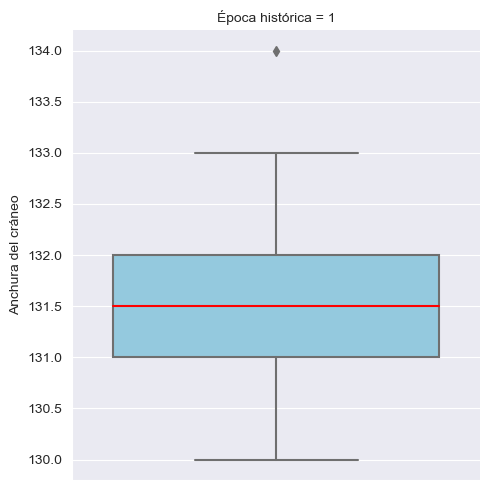

```python
sns.catplot(data = df_1 ,  y='Anchura del cráneo' , col ='Época histórica' , kind = 'box', color='skyblue',medianprops={'color':'red'} )
plt.show()
```

Del gráfico observamos un valor atípico en 134 y cómo los valores se concentran en torno a la mediana.

#### MEDIDAS DE TENDENCIA CENTRAL - NO CENTRAL - DISPERSION - FORMA - PREDINASTICO TARDIO

A continuación repetimos los mismos cálculos para los datos de la segunda muestra:

```python
#obtencion de algunos de las medidas de tendencia central y no central, calcularemos el resto a continuacion
valores_2 = pd.DataFrame(df_2['Anchura del cráneo'].describe())
valores_2.reset_index(inplace=True)
valores_2.rename(columns={'index':'Medida'},inplace = True)
valores_2.head(5)
```

|  | Medida | Anchura del cráneo |
| --- | --- | --- |
| 0 | count | 30.000000 |
| 1 | mean | 132.466667 |
| 2 | std | 1.008014 |
| 3 | min | 131.000000 |
| 4 | 25% | 132.000000 |

Calculamos de la misma forma que antes la moda, el rango, la varianza y el voeficiente de variación de Pearson:

```python
#calculo de la moda para grupo 2 (tardio)
moda_2  = int(df_2['Anchura del cráneo'].mode())
```

```python
#calculo del rango (valor maximo - valor minimo)
rango_2 = df_2['Anchura del cráneo'].max() - df_2['Anchura del cráneo'].min()
```

```python
#calculo de la varianza
varianza_2 = df_2['Anchura del cráneo'].var()
```

```python
#calculo del coeficiente de variacion de Pearson -- DESVIACION STANDAR / MEDIA
coef_var_P_2 = valores_2.loc[2][1]/valores_2.loc[1][1]
```

A continuación, calculamos el coeficiente de Asimetría de Fisher y el de Curtosis:

```python
df_2['Xi - Media'] = df_2['Anchura del cráneo'] - valores_2.loc[1][1]
df_2['(Xi - Media)*3'] = df_2['Xi - Media']**3
df_2['(Xi - Media)*4'] = df_2['Xi - Media']**4
df_2.head(5)
```

|  | Época histórica | Anchura del cráneo | Xi - Media | (Xi - Media)*3 | (Xi - Media)*4 |
| --- | --- | --- | --- | --- | --- |
| 30 | 2 | 132 | -0.466667 | -0.101630 | 0.047427 |
| 31 | 2 | 133 | 0.533333 | 0.151704 | 0.080909 |
| 32 | 2 | 131 | -1.466667 | -3.154963 | 4.627279 |
| 33 | 2 | 133 | 0.533333 | 0.151704 | 0.080909 |
| 34 | 2 | 133 | 0.533333 | 0.151704 | 0.080909 |

```python
Coef_Fisher_2=df_2['(Xi - Media)*3'].sum()/((df_2['Época histórica'].count()-1)*mt.pow(valores_2.loc[2][1],3))
Coef_Fisher_2
```

```
0.1918262295493577
```

```python
coeficiente_Curtosis_2 = df_2['(Xi - Media)*4'].sum()/((df_2['Época histórica'].count()-1)*mt.pow(valores_2.loc[2][1],4)) -3
coeficiente_Curtosis_2
```

```
-0.2800290739337874
```

Como obtenemos un coeficiente de curtosis menor que 0 por lo que podemos anticipar una distribucion **platicúrtica**.

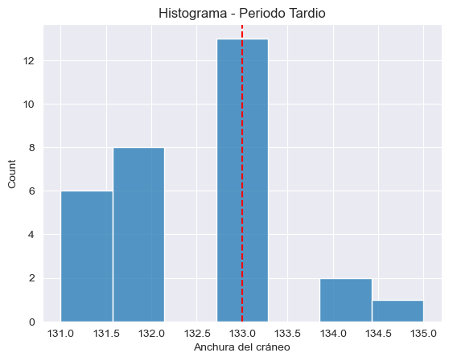

```python
sns.histplot(data=df_2['Anchura del cráneo'] )
plt.axvline(x=valores_2.loc[5][1], color='red', linestyle='--')
plt.title('Histograma - Periodo Tardio')
plt.show()
```

Unimos las medidas y coeficientes calculados hasta ahora:

```python
Medida_2 = ['moda','rango','varianza','CoeficientePerson','CoeficienteFisher','CoeficienteCurtosis']
Anchura_del_Craneo_2 = [moda_2,rango_2, varianza_2,coef_var_P_2,Coef_Fisher_2,coeficiente_Curtosis_2]

medidas_2 = pd.DataFrame({'Medida':Medida_2,'Anchura del cráneo':Anchura_del_Craneo_2})
medidas_2
```

|  | Medida | Anchura del cráneo |
| --- | --- | --- |
| 0 | moda | 133.000000 |
| 1 | rango | 4.000000 |
| 2 | varianza | 1.016092 |
| 3 | CoeficientePerson | 0.007610 |
| 4 | CoeficienteFisher | 0.191826 |
| 5 | CoeficienteCurtosis | -0.280029 |

#### MEDIDAS PERIODO TRARDIO

Juntamos todas las medidas de la distribución del periodo tardío en un mismo dataframe:

```python
valores_w_2 = pd.concat([valores_2,medidas_2],ignore_index=True)
valores_w_2
```

|  | Medida | Anchura del cráneo |
| --- | --- | --- |
| 0 | count | 30.000000 |
| 1 | mean | 132.466667 |
| 2 | std | 1.008014 |
| 3 | min | 131.000000 |
| 4 | 25% | 132.000000 |
| 5 | 50% | 133.000000 |
| 6 | 75% | 133.000000 |
| 7 | max | 135.000000 |
| 8 | moda | 133.000000 |
| 9 | rango | 4.000000 |
| 10 | varianza | 1.016092 |
| 11 | CoeficientePerson | 0.007610 |
| 12 | CoeficienteFisher | 0.191826 |
| 13 | CoeficienteCurtosis | -0.280029 |

Hacemos el correspondiente diagrama de bigotes:

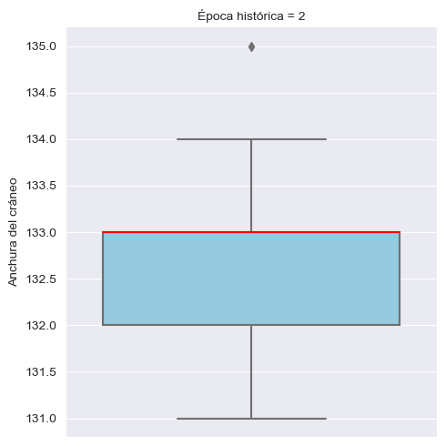

```python
sns.catplot(data = df_2 ,  y='Anchura del cráneo' , col ='Época histórica' , kind = 'box', color='skyblue',medianprops={'color':'red'} )
plt.show()
```

Como podemos ver en el diagrama de caja para el periodo tardio, se tiene un valor atípico en 135. Además, la mediana coincide con el tercer cuartil, lo que supone que todos los valores entre la mediana y el tercer cuartil son de 133.

#### COMPARATIVA DE LOS DIAGRAMAS DE CAJA PARA AMBOS PERIODOS

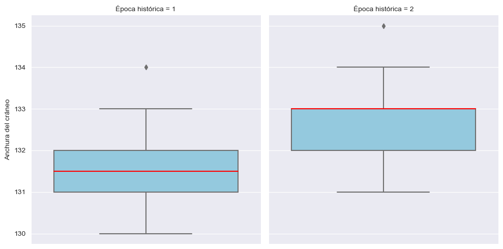

```python
sns.catplot(data = df ,  y='Anchura del cráneo' , col ='Época histórica' , kind = 'box', color='skyblue',medianprops={'color':'red'} )
plt.show()
```

Podemos concluir así que la anchura del cráneo tiende a aplanarse con el paso del tiempo. En el periodo temprano, los valores entre los cuartiles 25 y 75 se encontraban entre 131 y 132, teniendo la mediana en 131.5. Sin embargo, en el periodo tardío, los valores entre los cuartiles 25 y 75 se desplazan encontrándose entre los valores 132 (el límite superior del anterior periodo) y 133 (el máximo valor sin ser outlier del periodo temprano). Además el outlier del primer periodo no lo sería en el periodo tardío.

### Apartado b)

Para ambas distribuciones vamos a poner las siguientes hipótesis a contrastar:

- H_0 -> la distribucion 1-2 sigue una muestra normal
- H_1 -> La distribucion 1-2 no sigue una muestra normal

Para realizar el test, vamos a estandarizar los datos en primer lugar para ambas muestras y usaremos la librería *stats* de *Scipy* para realizar el test de kolmogorov con la función `ktest()`, especificamos que es un contraste de hipótesis sobre la distribución normal con el parámetro que pasamos a la función de "norm".

```python
# conversion de los df filtrado a np.array para aprovechar sus caracteristicas
submuestra1 = np.array(df_1['Anchura del cráneo'])
submuestra2 = np.array(df_2['Anchura del cráneo'])

# Asegurarse de que las submuestras sean arreglos de una sola columna
submuestra1 = submuestra1.reshape(-1, 1)
submuestra2 = submuestra2.reshape(-1, 1)

# Inicializar standarscaler de scktlearn
scaler1 = StandardScaler()
scaler2 = StandardScaler()

# Normalizar las muestras
submuestra1 = scaler1.fit_transform(submuestra1)
submuestra2 = scaler2.fit_transform(submuestra2)

#llevar las submuestras a matriz unidmensional
submuestra1=submuestra1.flatten()
submuestra2=submuestra2.flatten()

# Aplicar la prueba de Kolmogorov-Smirnov
statistic1, pvalue1 = stats.kstest(submuestra1, 'norm')
statistic2, pvalue2 = stats.kstest(submuestra2, 'norm')

# Imprimir los resultados
print("Resultados de la submuestra 1:")
print(f"Estadístico: {statistic1}, Valor p: {pvalue1}")
if pvalue1 > 0.05:
    print("La submuestra 1 sigue una distribución normal")
else:
    print("La submuestra 1 no sigue una distribución normal")

print("\nResultados de la submuestra 2:")
print(f"Estadístico: {statistic2}, Valor p: {pvalue2}")
if pvalue2 > 0.05:
    print("La submuestra 2 sigue una distribución normal")
else:
    print("La submuestra 2 no sigue una distribución normal")
```

```
Resultados de la submuestra 1:
Estadístico: 0.2460415331404474, Valor p: 0.04379464338101191
La submuestra 1 no sigue una distribución normal

Resultados de la submuestra 2:
Estadístico: 0.23809252465886277, Valor p: 0.055727049848177
La submuestra 2 sigue una distribución normal
```

**Resultados del test de contraste de hipótesis de KOLMOGROV-SMIRNOV**

La muestra 1 posee un p-valor de 0.04379464338101191 y puesto que este valor es menor que 0.05 que es el nivel de significación, se rechaza la hipótesis nula, por lo que podemos aceptar la hipótesis de que la primera submuestra no sigue una distribución normal.

La muestra 2 posee un p-valor de 0.055727049848177, mayor que el nivel de significación 0.05, lo que nos permite aceptar la hipótesis nula de que la segunda submuestra sigue una distribución normal.

## Ejercicio 2

**a) Con los mismos datos del ejercicio anterior, obtener un intervalo de confianza (de nivel 0.9, de nivel 0.95 y de nivel 0.99) para la diferencia entre las medias de la anchura de la cabeza en ambos periodos históricos. Interpretar los resultados obtenidos y discutirlos en función del test de normalidad del ejercicio anterior. La interpretación debe ser rigurosa desde el punto de vista estadístico y también marcada por el story telling, es decir, comprensible desde el punto de vista de las variables respondiendo a la pregunta ¿en qué época la cabeza era más ancha?**

**b) Utilizar el test t para contrastar la hipótesis de que ambas medias son iguales. Explicar qué condiciones se deben cumplir para poder aplicar ese contraste. Determinar si se cumplen. Admitiremos de forma natural la independencia entre ambas muestras, así que esa condición no hace falta comprobarla.**

Comentario antes de resolver el ejercicio:

#### Obtención de Intervalos de Confianza:

Con base en el Teorema Central del Límite (TCL), que establece que para tamaños de muestra suficientemente grandes la distribución de la media muestral se aproxima a una distribución normal, procederemos a calcular intervalos de confianza para la diferencia entre las medias de la anchura de la cabeza en ambos periodos históricos.

Dado que las muestras son lo suficientemente grandes (suposición que haremos para simplificar la resolución), aplicaremos el TCL para justificar el cálculo de intervalos de confianza, asumiendo la normalidad de la primera muestra. Utilizaremos niveles de confianza del 90%, 95%, y 99% para obtener intervalos de confianza con diferentes grados de precisión.

Es importante señalar que, aunque el TCL proporciona una justificación teórica, la interpretación de los resultados debe ser considerada tanto desde el punto de vista estadístico como del "storytelling", es decir, debe ser comprensible y relevante desde la perspectiva de las variables en cuestión. En este contexto, buscaremos responder a la pregunta de en qué época la cabeza era más ancha a través de la interpretación de los intervalos de confianza.

#### Test t para Contrastar Hipótesis de Medias Iguales:

La aplicación del test t para contrastar la hipótesis de que ambas medias son iguales se justificará también mediante el TCL. Asumiremos que las muestras son lo suficientemente grandes para aplicar este teorema. Aunque una de las muestras no sigue una distribución normal según el test de Kolmogorov-Smirnov, el tamaño de la muestra permitirá que el test t sea robusto y proporcione resultados confiables.

Es esencial recordar que, en la práctica, la validez de estas aproximaciones puede depender de la forma de la distribución original y de otros factores. Sin embargo, con muestras grandes, el TCL respalda el uso del test t siempre que se cumplan condiciones adicionales, como la homogeneidad de varianzas y la independencia de observaciones (que como veremos, en este caso se verifican).

En resumen, tanto para la obtención de intervalos de confianza como para la aplicación del test t, nos apoyaremos en el TCL, asumiendo que el tamaño de las muestras es lo suficientemente grande. Este enfoque permite abordar los análisis estadísticos a pesar de la posible falta de normalidad en una de las muestras, respaldando la validez de los resultados obtenidos.

### Apartado a)

Para este análisis, asumiremos:

#### Contraste de Hipótesis

H0: Las muestras tienen varianzas poblacionales iguales S1 = S2

H1: Las muestras tienen varianzas poblacionales diferentes S1!=S2

#### Configuración del Contraste

- Nivel de confianza: 90%
- Prueba de dos colas (evaluando igualdad o diferencia entre varianzas).
- Hipótesis de normalidad: Aunque la primera muestra no cumplió con la normalidad en el ejercicio anterior, asumiremos normalidad basándonos en el Teorema Central del Límite (TCL) como se ha aclarado anteriormente.

#### Cálculos

- Grados de libertad para ambas muestras: 29 (30-1).
- Nivel de significancia (alpha): 0.1 (10%).
- Prueba de dos colas implica alpha/2 para los valores críticos de F.

```python
from scipy.stats import f

gl1= valores_1.loc[0][1] - 1  #cantidad de elementos de la muestra1 - 1
gl2= valores_2.loc[0][1] - 1  #cantidad de elementos de  la muestra 2 -1
alfa_medios = 0.05
```

```python
valor_tabla_f_derecha = f.ppf(1-alfa_medios,gl1,gl2)   #valor critico por la derecha de la curva F
```

```python
valor_tabla_f_izquierda = 1/valor_tabla_f_derecha     #al tener el mismo numero de GL la inversa es el valor de la izquierda
```

```python
print("La zona de aprobacion de la H0 es:",valor_tabla_f_izquierda,"<F<",valor_tabla_f_derecha)
```

```
La zona de aprobacion de la H0 es: 0.5373999648406917 <F< 1.8608114354760754
```

```python
Fisher = mt.pow (valores_1.loc[2][1],2)/mt.pow(valores_2.loc[2][1],2)
Fisher
```

```
0.6606334841628961
```

A continuación, aunque vemos que el valor F se encuentra en el intervalo y por lo tanto podemos decir que no hay evidencias para rechazar la hipótesis nula de que las varianzas son iguales, vamos a representarlo en un gráfco con ayuda de la librería `Matplotlib` de Python:

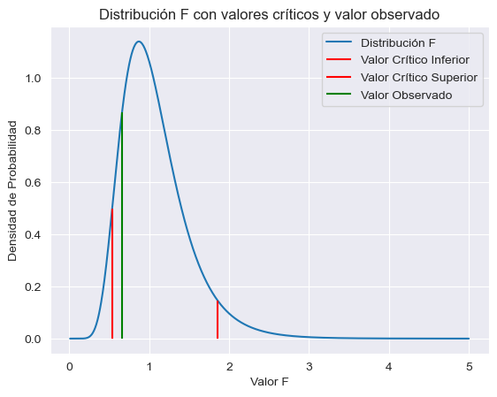

```python
import numpy as np
import matplotlib.pyplot as plt
from scipy.stats import f

# Definir el rango de valores de F
f_values = np.linspace(0.01, 5, 1000)

# Calcular la distribución F
f_distribucion = f.pdf(f_values, gl1, gl2)

# Graficar la distribución F
plt.plot(f_values, f_distribucion, label='Distribución F')

# Graficar los valores críticos y el valor observado
plt.vlines(valor_tabla_f_izquierda, 0, f.pdf(valor_tabla_f_izquierda, gl1, gl2), colors='r', label='Valor Crítico Inferior')
plt.vlines(valor_tabla_f_derecha, 0, f.pdf(valor_tabla_f_derecha, gl1, gl2), colors='r', label='Valor Crítico Superior')
plt.vlines(Fisher, 0, f.pdf(Fisher, gl1, gl2), colors='g', label='Valor Observado')

# Configurar la leyenda y etiquetas
plt.legend()
plt.xlabel('Valor F')
plt.ylabel('Densidad de Probabilidad')
plt.title('Distribución F con valores críticos y valor observado')

# Mostrar la gráfica
plt.show()
```

Finalmente, teninendo que las muestras son independientes, las varianzas desconocias y además estas son supuestas iguales, y amparándonos en el TCL para la hipótesis de normalidad de ambas muestras. Podemos calcular el intervalo de confianza para la diferencia de medias:

```python
from scipy.stats import t

diferencia_medias = valores_1.loc[1][1] - valores_2.loc[1][1]
n1=valores_1.loc[0][1]
n2=valores_2.loc[0][1]
s1 = valores_1.loc[2][1]
s2 = valores_2.loc[2][1]
grados_libertad = n1+n2-2
error_standar  = mt.sqrt((((n1*mt.pow(s1,2)+n2*mt.pow(s2,2))*((1/n1)+(1/n2)))/(grados_libertad)))
#el error standar para la diferencia de medias, es el determinado ya que las varianzas poblacionales son desconocidas pero iguales

intervalo_90 = stats.t.interval(0.90,grados_libertad,loc=diferencia_medias,scale=error_standar)
intervalo_95 = stats.t.interval(0.95,grados_libertad,loc=diferencia_medias,scale=error_standar)
intervalo_99 = stats.t.interval(0.99,grados_libertad,loc=diferencia_medias,scale=error_standar)
```

```python
print("los intervalos de confianza para la diferencia de medias con un 90% de confianza es:" ,intervalo_90)
print("--------------------------------------------------------------------------------------------------------------")
print("los intervalos de confianza para la diferencia de medias con un 95% de confianza es:" ,intervalo_95)
print("--------------------------------------------------------------------------------------------------------------")
print("los intervalos de confianza para la diferencia de medias con un 99% de confianza es:" ,intervalo_99)
```

```
los intervalos de confianza para la diferencia de medias con un 90% de confianza es: (-1.3365370178425788, -0.5301296488240955)
--------------------------------------------------------------------------------------------------------------
los intervalos de confianza para la diferencia de medias con un 95% de confianza es: (-1.4161777177709258, -0.4504889488957485)
--------------------------------------------------------------------------------------------------------------
los intervalos de confianza para la diferencia de medias con un 99% de confianza es: (-1.5757582313054241, -0.2909084353612502)
```

Los intervalos de confianza para los tres niveles determinados (90%, 95%, 99%) excluyen el valor 0, como se evidencia en los resultados previos. En estos tres casos, la diferencia entre las medias es estadísticamente significativa y no puede atribuirse al azar. En otras palabras, los cráneos de ambas poblaciones son notablemente distintos, siendo los cráneos del periodo temprano menos anchos que los del periodo tardío.

### Apartado b)

Para poder probar la diferencia de medias de dos poblaciones. debemos considerar que se deben cumplir 3 condiciones:

1. Normalidad de los datos (lo suponemos cierto para la primera muestra por el TCL y para la segunda por el test de Kolmogorov-Smirnov).
2. Homogenidad de la varianza (se demostró en el apartado anterior).
3. Independencia de las observaciones (se puede suponer cierto por el enunciado).

Como todas se verifican, procedemos a presentar las hipótesis a contrastar:

H0: las medias de ambas muestras son iguales --------- M0 = M1  
H1: Las medias de ambas muestras son diferentes ------ M0 != M1

Se trata de una prueba de dos colas nuevamente, con un intervalo de confianza al 95% lo que hace que alfa sea 0.025 a cada lado de la curva. Los grados de libertad serán en total N1 + N2 - 2 = 30 + 30 -2 = 58

```python
#calcularemos los valores cirticos correspondeintes a la distribucion T

alfa = 0.05
alfa_medios = alfa/2

lim_sup = t.ppf(1-alfa_medios,grados_libertad)
lim_inf = t.ppf(alfa_medios,grados_libertad)

print("la zona de aceptacion para la prueba es :",lim_inf,",",lim_sup)
```

```
la zona de aceptacion para la prueba es : -2.0017174830120927 , 2.0017174830120923
```

#### Cálculo del Valor T

El cálculo del valor t se realiza mediante la siguiente fórmula:

t = (M_muestral1 - M_muestral2 - (M_poblacional1 - M_poblacional2)) / Error Estándar Estimado

Dado que estamos probando en la hipótesis nula (H0) que las medias poblacionales son iguales, la diferencia de las medias poblacionales en la fórmula anterior es 0, es decir, (M_poblacional1 - M_poblacional2) = 0.

Esto nos lleva al siguiente cálculo simplificado para el valor t:

t = (M_muestral1 - M_muestral2) / Error Estándar Estimado

Con estos valores listos, procederemos a calcular el valor t observado.

```python
#calculo del error estandar, similar al ejercicio anterior

valor_critico =  float(diferencia_medias)/(error_standar)

print("el valor critico de T es :", valor_critico)
```

```
el valor critico de T es : -3.869299739267822
```

Observamos que el valor crítico de T no se encunetra dentro del intervalo para aceptar la Ho. A continuación lo representamos en un gráfico:

```
El valor crítico de T es: -3.869299739267822
```

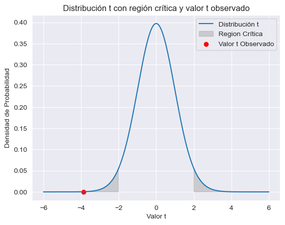

```python
valor_critico = float(diferencia_medias) / error_standar

print("El valor crítico de T es:", valor_critico)

# Definir el rango de valores de t
t_values = np.linspace(-6, 6, 1000)

# Calcular la distribución t
t_distribucion = t.pdf(t_values, grados_libertad)

# Graficar la distribución t
plt.plot(t_values, t_distribucion, label='Distribución t')

# Shade the regions corresponding to critical values
plt.fill_between(t_values, 0, t_distribucion, where=(t_values < lim_inf) | (t_values > lim_sup), color='gray', alpha=0.3, label='Region Crítica')

# Mark the observed t-value
plt.scatter(valor_critico, t.pdf(valor_critico, grados_libertad), color='red', label='Valor t Observado')

# Configurar la leyenda y etiquetas
plt.legend()
plt.xlabel('Valor t')
plt.ylabel('Densidad de Probabilidad')
plt.title('Distribución t con región crítica y valor t observado')

plt.show()
```

#### Interpretación de los Resultados

Al observar la gráfica, notamos que el valor crítico de t se encuentra en la zona de rechazo de la hipótesis nula (H0). Esto nos permite afirmar que existe una diferencia significativa entre las medias de ambas poblaciones. Estas diferencias no son atribuibles a factores aleatorios; estadísticamente, podemos concluir que las dos muestras son diferentes.